# 秋の長さの解析：気温分布の比較（全国版）

気象予報士会 東北支部6月例会

岩渕 巧 (No.3682)

2026-06-06

## 前回の宿題

### 確率密度関数の四季分割

四季毎の確率密度関数を重ね合わせると通年の確率密度関数と一致するか？について以下の通り検証を行った。 確率密度関数ではなく、ヒストグラムの積み上げで比較してみる。

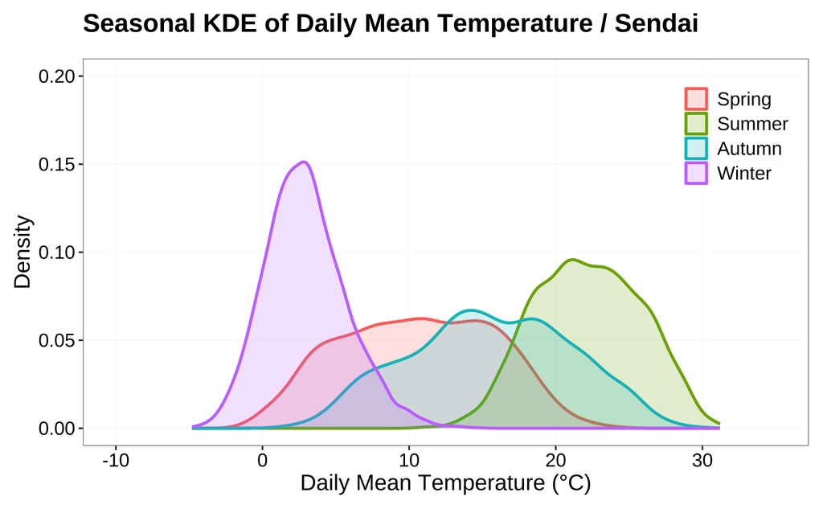

Figure 1: 四季別確率密度曲線

### ヒストグラムによる比較

通年のヒストグラムが Figure 2 、四季別のヒストグラムを積み上げたものが Figure 3 である。

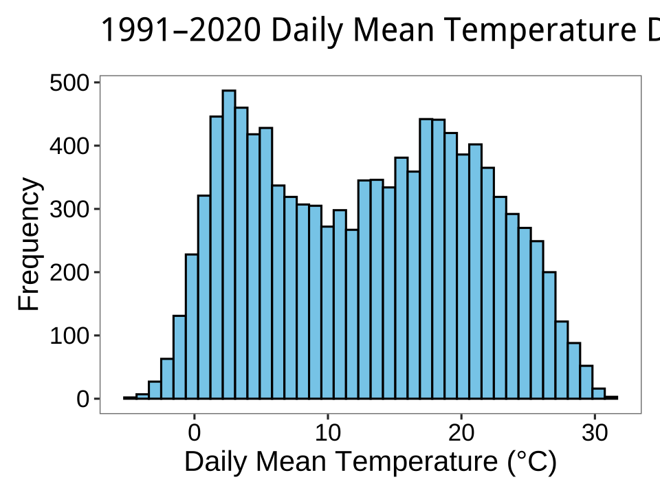

Figure 2: 通年のヒストグラム

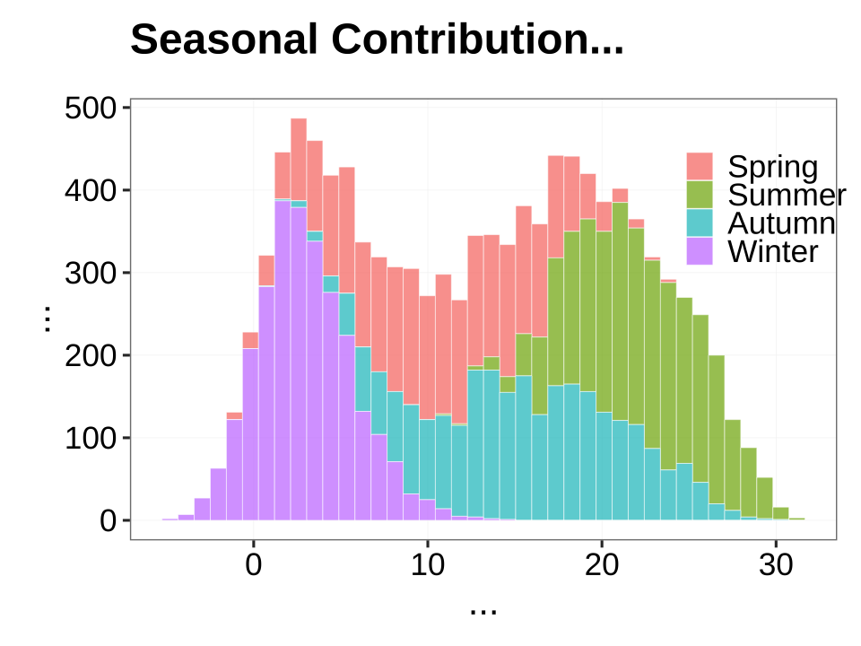

Figure 3: 積み上げヒストグラム

Figure 2 と Figure 3 が一致していることから、四季ヒストグラム（確率密度関数）は妥当といえる。

## 追加検証（信頼区間の付記）

確率密度関数のプロットにブートストラップ法※による95%信頼区間を帯状に表示してみた（ Figure 4 ）。 また、気象現象に特有の自己相関によってブレを過小評価することがあるため、数日〜数週間の「ブロック（塊）」ごとにデータをまとめてシャッフルする「ブロック・ブートストラップ法（Block Bootstrap）」で比較してみる（ Figure 5）。

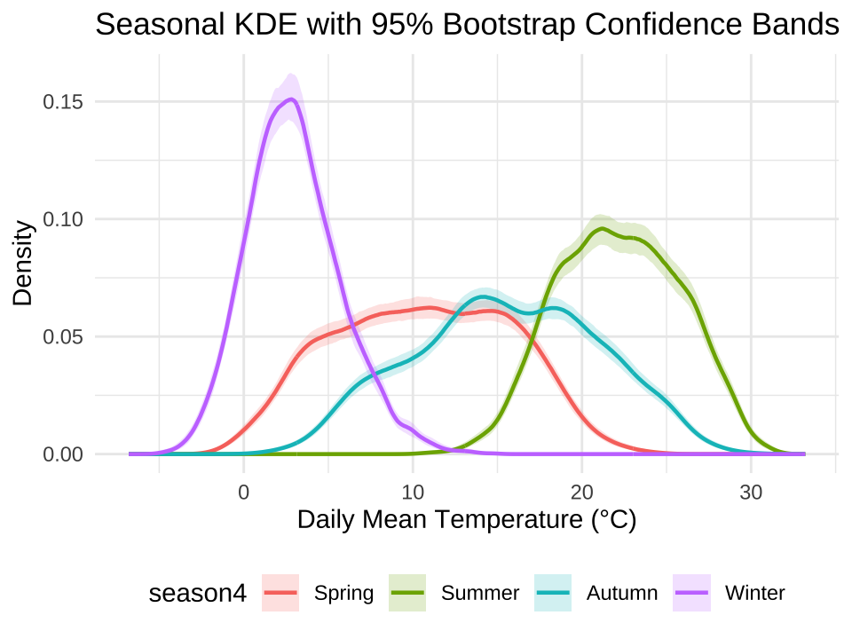

Figure 4: ブートストラップ法

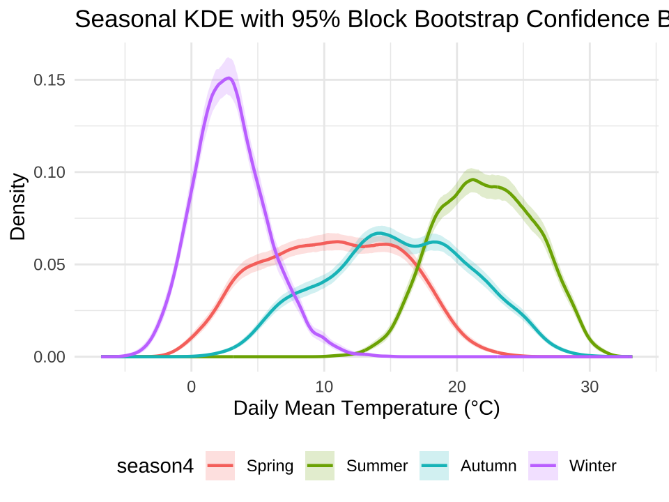

Figure 5: ブロックブートストラップ法

**ブートストラップ法による解析結果の解釈**

- 信頼区間（シェード）の縦幅は、どの季節も裾野で狭い。極端な気温が出現する頻度は低い。
- 夏の山部はシェードが厚く2峰型がハッキリしない。2峰型に見えるのは、年によるブレの範囲内なのかもしれない。
- 秋はシェードを掛けても2峰型が残っている。秋が夏から冬にかけての季節の入れ替わりの時期であることを示しているように見える。
- 春は秋に比べて全体的になだらかで、シェードを掛けても様相は変わらない。「季節の入れ替わりの時期」であるが、秋とはメカニズムが違うのだろうか。
- ブロックブートストラップ法による信頼区間は、ブートストラップ法による結果と大差ないことがわかった。

※元のデータから重複を許して何度もランダムにサンプリングし（ここでは500回）、その都度KDEを計算する。 500本のKDEの「下位2.5%」と「上位97.5%」のラインを結ぶことで、ノンパラメトリックに95%信頼区間の「帯（Confidence Band）」を作成する。

### 生成AIによる春と秋のメカニズムの違い解説

参考までに生成AI（Google Gemini）の解説です。

春（3・4・5月）のピンクの山は、秋のような明瞭な2峰を持たず、お椀をひっくり返したように全体的になだらかで「ぼんやり」していますよね。同じ「季節の移行期（過渡期）」なのに、なぜこれほど様相が違うのでしょうか。ここには、日本の気候（特に太平洋側・東北）の素晴らしいメカニズムが隠されています。

1. 気温の「下がり方（秋）」と「上がり方（春）」の特性の違い
   - 秋： 夏の太平洋高気圧が後退したあと、大陸からの寒気が「一歩一歩、段階的に（ステップ状に）」日本を覆ってきます。そのため、特定の気温帯でしばらく落ち着く時期（＝山）ができやすいです。
   - 春： 冬のシベリア高気圧が衰退していく過程で、日本付近は低気圧と高気圧が非常に速いサイクルで交互に通過します（周期変化）。気温が階段状ではなく、「三寒四温」を繰り返しながら、文字通り日替わりで目まぐるしく変化しながら上昇していくため、特定の気温帯に留まることができず、分布全体が万遍なくなだらか（ぼんやり）になります。
2. 仙台特有の春の伏兵「やませ」の影響
   - さらに仙台（東日本太平洋側）特有の事情として、5月頃になるとオホーツク海高気圧から冷たく湿った北東風（やませ）が吹き込むようになります。
   - これにより、本来なら初夏に向かって暖かくなるはずの時期に、ガクッと気温が下がる日（真冬並みの寒さになる日）が突発的に混ざります。
   - この「本来の春の暖かさ」と「やませによる急激な冷え込み」が同じ期間内にごちゃ混ぜにブレンドされるため、春のKDEはピークが引き延ばされ、境界線が曖昧でぼんやりとした形になるのです。

## 日本各地の平均気温解析

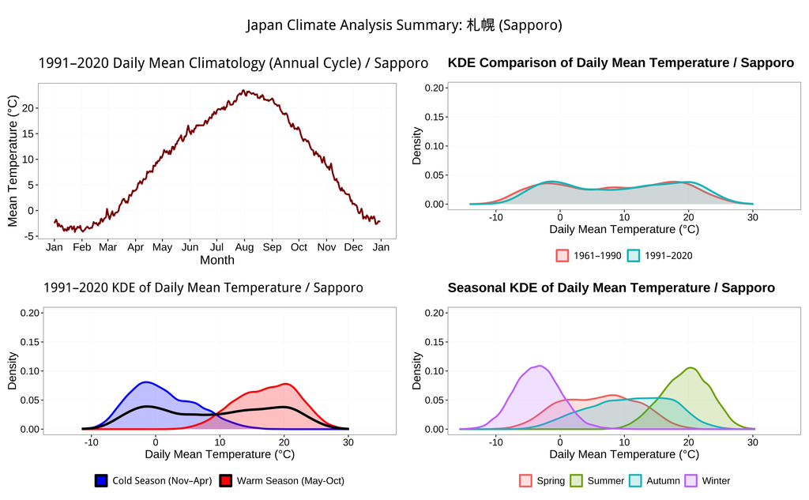

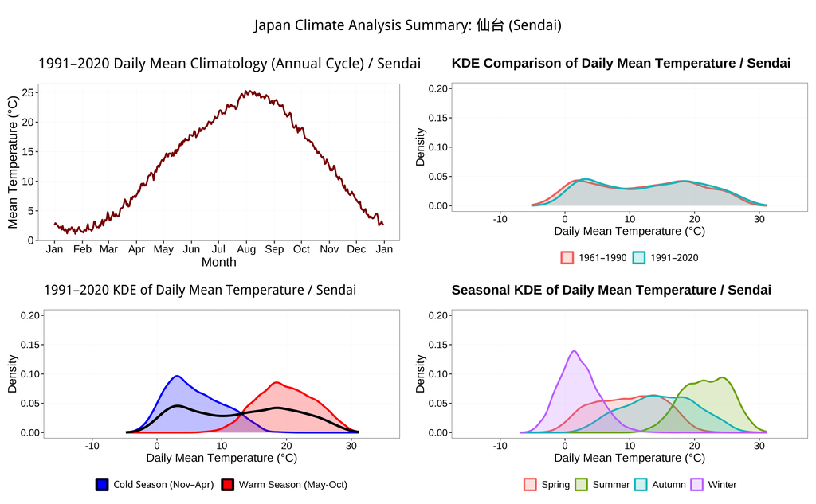

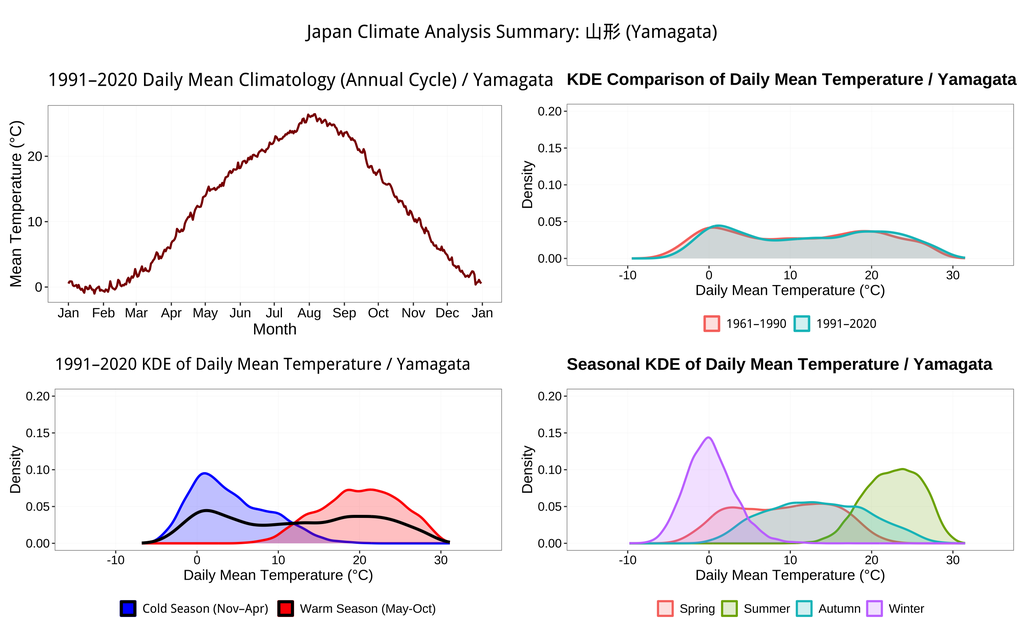

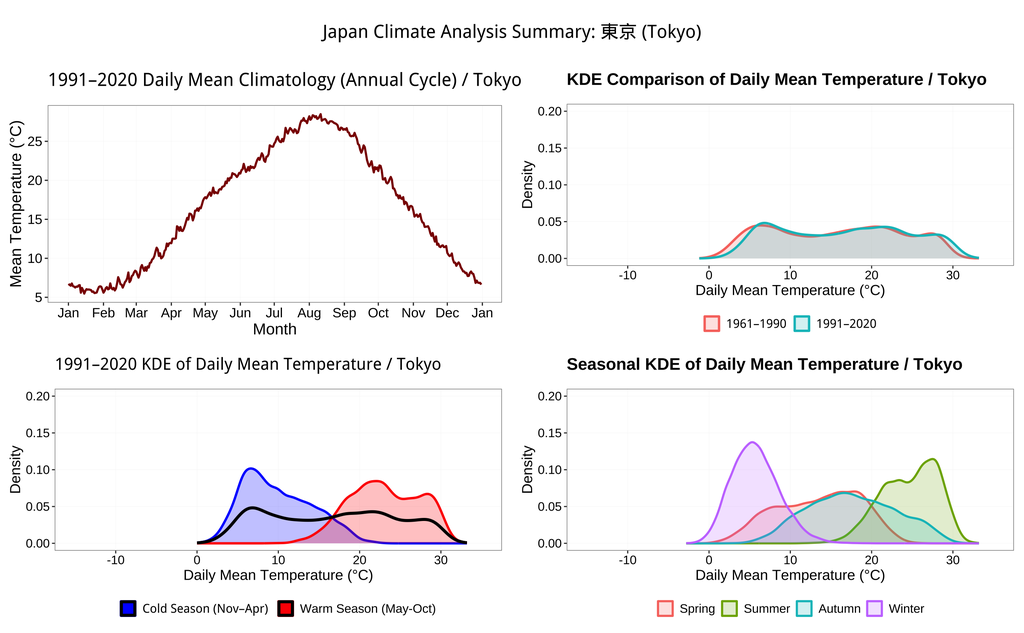

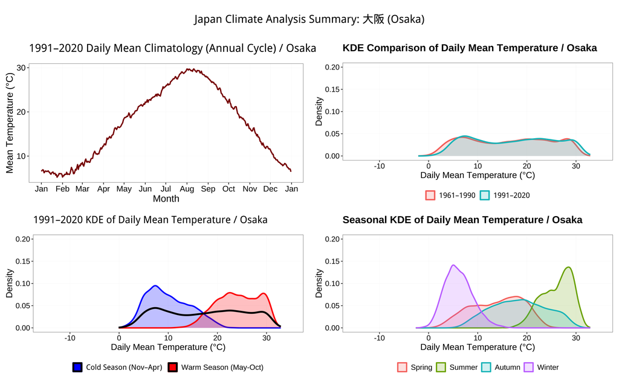

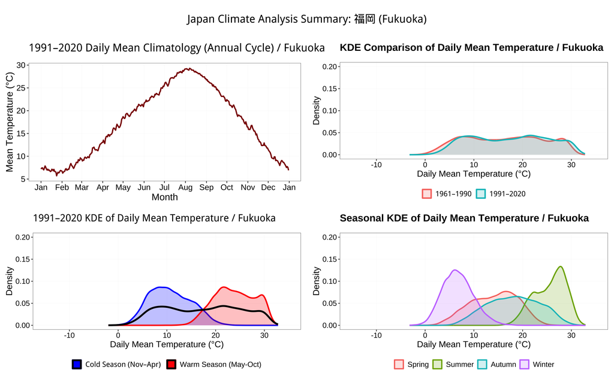

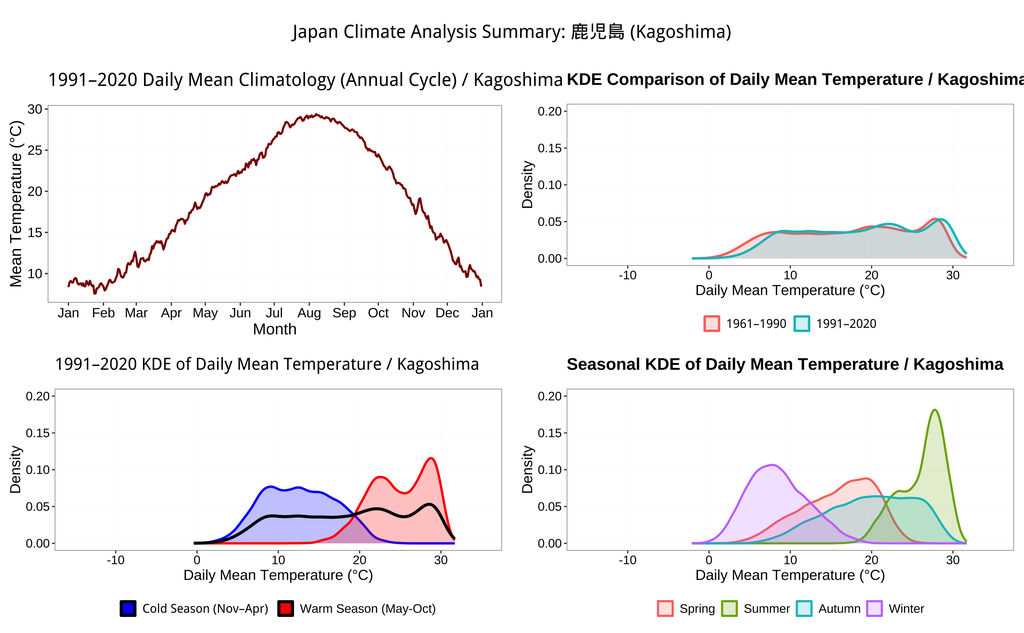

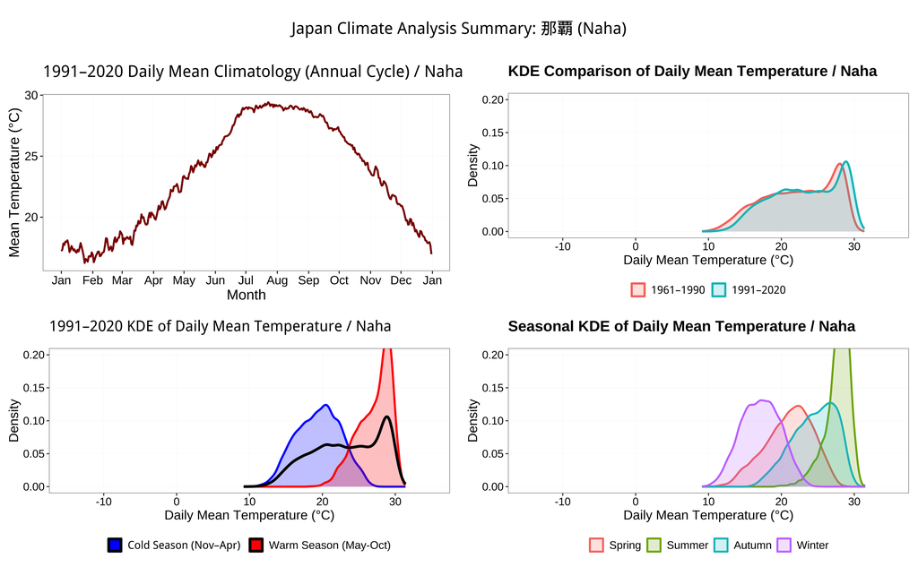

## 各地の特徴

- 札幌、山形の夏は綺麗な山形なのに対し、仙台、東京、大阪、福岡の夏は2峰型、これは梅雨の影響が考えられる
- 南下するほど夏の高温部のピークが鋭くなり、鹿児島では顕著になる
- 那覇は他の地点と形状が全く違い、各季節のばらつきが少ない，特に夏のばらつきの少なさが顕著である

## 世界各地（Open-Meteo）6地点の解析

Open-Meteo（https://open-meteo.com）の再解析データから緯度経度指定で代表的な地点のデータを取得した。

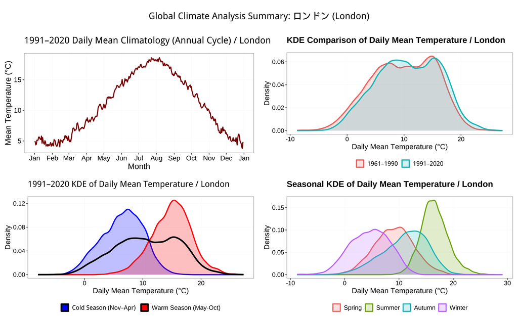

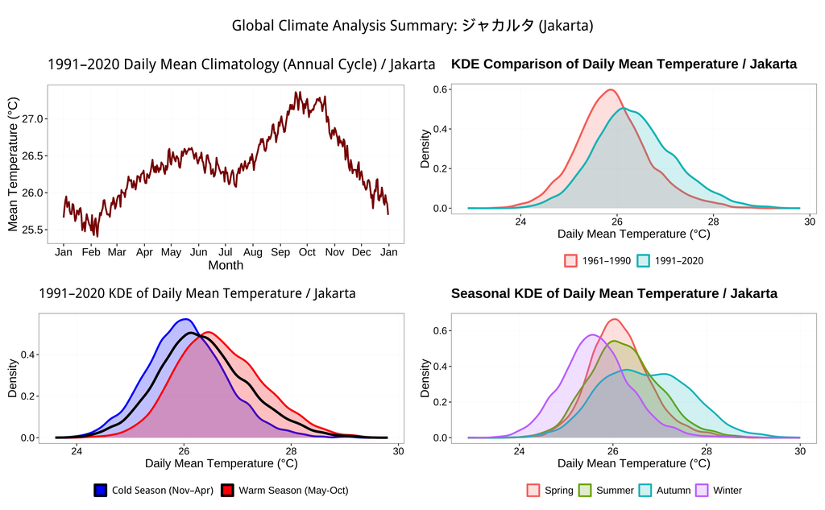

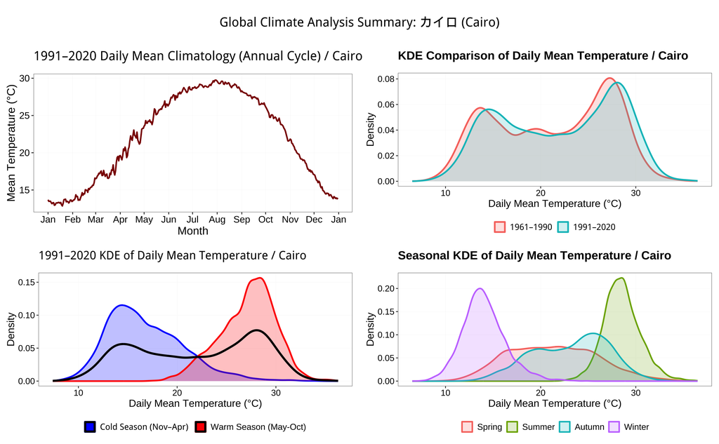

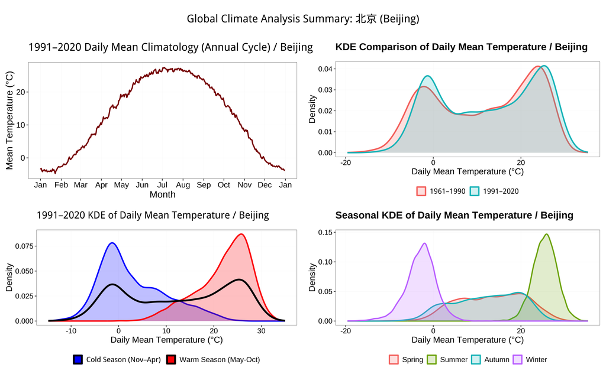

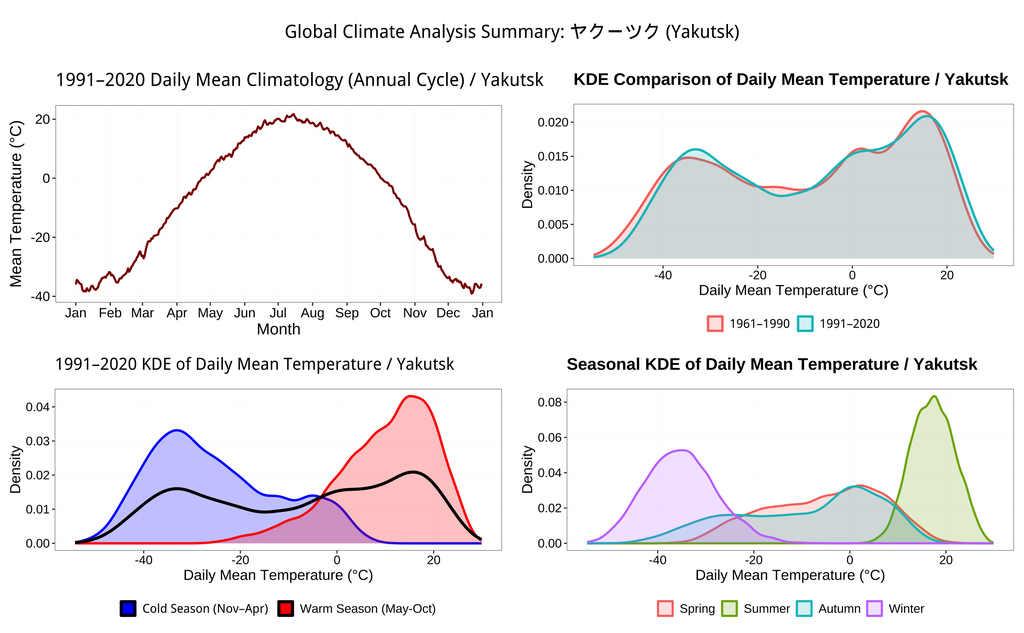

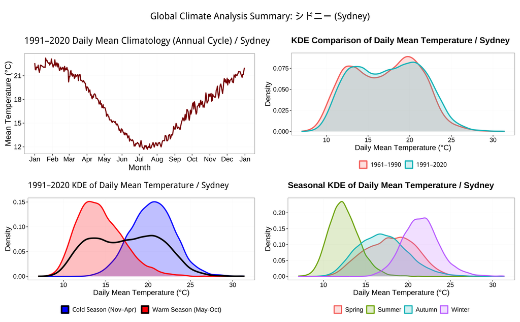

## 世界6地点の気温分布比較

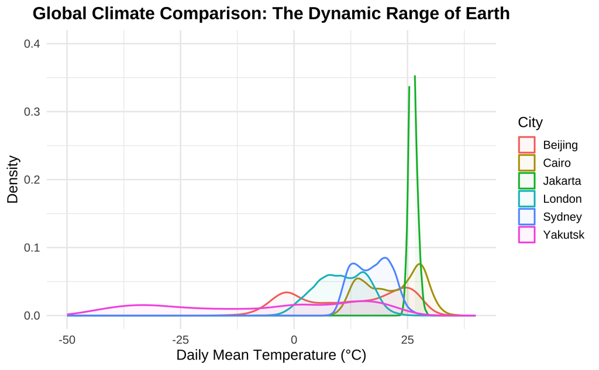

- ヤクーツクの年較差の大きさ、ジャカルタの年較差の小ささが特徴的
- ロンドンとシドニーは緯度の関係で温度分布がやや異なるが、形状そのものは比較的似ている
- 最も温かい気温を比較すると、ジャカルタよりカイロ、北京の方が高い、ジャカルタは海洋の影響で極端な高温にならず、内陸のカイロ、北京は極端な高温が発生するものと考えられる